# R basics & time series datasets

# 1 Introduction

## 1.1 About

## 1.2 Structure of the crash course

1. **Introduction** to R basics & datasets + summary statistics
2. **Theory 1**: randomness, stationarity, unit roots, random walk
3. **Theory 2**: autocorrelation, ARMA models, predictive regressions
4. **Advanced models** (VAR, GARCH and neural networks) and prediction

# 2 Packages

There are currently more than 23,000 packages on the [CRAN](https://cran.r-project.org/web/packages/).  
But many more exist on [github](https://github.com/). They are however not vetted/verified.

## 2.1 Installation

Just run the following chunk:

```r
if(!require("openxlsx")){install.packages(c("tidyverse", "openxlsx", "reticulate", "quantmod", "feasts",
                                            "fable", "crypto2", "ggsci"))}
```

## 2.2 Loading

library() is the equivalent to “import…” in python.

```r
library(tidyverse)  # THE library for data science
library(openxlsx)   # A cool package to deal with Excel files/formats
library(quantmod)   # Package for financial data extraction
library(tsibble)    # TS with dataframes framework
library(fable)      # Package for time-series models & predictions
library(feasts)     # Package for time-series analysis
library(crypto2)    # Package to access crypto data
library(ggsci)      # For cool plot palettes & colors
library(WDI)        # For World Bank data
```

# 3 Things to know with R

## 3.1 Data structures, assigning & indexing

The equal sign “=” goes both ways. Arrows don’t!

```r
a <- 6
a
```

```
[1] 6
```

Vectors of integers….

```r
1:12
```

```
 [1]  1  2  3  4  5  6  7  8  9 10 11 12
```

```r
12:1
```

```
 [1] 12 11 10  9  8  7  6  5  4  3  2  1
```

Custom vectors. This syntax is strange (compared to python/MATLAB), but super **IMPORTANT** in R.  
Essentially, you embed the elements with the simple **c()** function.

```r
c(2, 3, 5, 8)
```

```
[1] 2 3 5 8
```

**Matrices**.

First method: stacking vectors (or smaller matrices).

```r
rbind(1:5, 2:6)
```

```
     [,1] [,2] [,3] [,4] [,5]
[1,]    1    2    3    4    5
[2,]    2    3    4    5    6
```

Second method: filling with values.

```r
matrix(1:12, nrow = 3)
```

```
     [,1] [,2] [,3] [,4]
[1,]    1    4    7   10
[2,]    2    5    8   11
[3,]    3    6    9   12
```

**Indexing**. It starts at one!

```r
M <- matrix(1:72, nrow = 6)
M
```

```
     [,1] [,2] [,3] [,4] [,5] [,6] [,7] [,8] [,9] [,10] [,11] [,12]
[1,]    1    7   13   19   25   31   37   43   49    55    61    67
[2,]    2    8   14   20   26   32   38   44   50    56    62    68
[3,]    3    9   15   21   27   33   39   45   51    57    63    69
[4,]    4   10   16   22   28   34   40   46   52    58    64    70
[5,]    5   11   17   23   29   35   41   47   53    59    65    71
[6,]    6   12   18   24   30   36   42   48   54    60    66    72
```

```r
M[2:5, 2:5] # rows first, then columns, ALWAYS!
```

```
     [,1] [,2] [,3] [,4]
[1,]    8   14   20   26
[2,]    9   15   21   27
[3,]   10   16   22   28
[4,]   11   17   23   29
```

**Dataframes**: ce can build them column-by-column. They are sometimes called “*tibbles*” in **R**.  
Most of the time, they are just imported from an external source (Excel spreadsheet).  
Below, we build one from scratch (this is often useful).

```r
n <- 12
data.frame(t = 1:n, x = rnorm(n), y = log(1:n))
```

| t | x | y |
| --- | --- | --- |
| 1 | 0.0258267 | 0.0000000 |
| 2 | 0.4544252 | 0.6931472 |
| 3 | 0.4985776 | 1.0986123 |
| 4 | 0.2389235 | 1.3862944 |
| 5 | 0.4431796 | 1.6094379 |
| 6 | -0.7331767 | 1.7917595 |
| 7 | -0.1567669 | 1.9459101 |
| 8 | 0.8342526 | 2.0794415 |
| 9 | -0.2398865 | 2.1972246 |
| 10 | -0.8488492 | 2.3025851 |
| 11 | -0.7814989 | 2.3978953 |
| 12 | 1.1017612 | 2.4849066 |

## 3.2 From type to type

Number $\rightarrow$ character.

```r
as.character(4)
```

```
[1] "4"
```

Character $\rightarrow$ number.

```r
as.numeric("4.5")
```

```
[1] 4.5
```

Text $\rightarrow$ date. Don’t forget the [ISO-8601 standard](https://en.wikipedia.org/wiki/ISO_8601)…

```r
as.Date("13/02/2005", format = "%d/%m/%Y")
```

```
[1] "2005-02-13"
```

Dates again.

```r
as.Date("09/11/01", format = "%m/%d/%y")
```

```
[1] "2001-09-11"
```

Factors.

```r
as.factor(c("Large", "Medium", "Small"))
```

```
[1] Large  Medium Small
Levels: Large Medium Small
```

## 3.3 The tidyverse + piping

The [**tidyverse**](https://tidyverse.org/) is an ecosystem of packages that are incredibly useful in data science tasks.  
In particular:

- [**dplyr**](https://dplyr.tidyverse.org/index.html) and [**tidyr**](https://tidyr.tidyverse.org/) for wrangling
- [**ggplot**](https://ggplot2.tidyverse.org/) for plotting
- [**stringr**](https://stringr.tidyverse.org/) for string management
- [**lubridate**](https://lubridate.tidyverse.org/) for date management

For this section, we need data. Below, we import macroeconomic information from the **World Bank API**.  
Technically speaking, this data is of **panel type**, but it’s great to work with.

```r
wb_data <- WDI(                             # World Bank data
  indicator = c(
    "pop" = "SP.POP.TOTL",                  # Population
    "pop_growth" = "SP.POP.GROW",           # Population growth
    "gdp_percap" = "NY.GDP.PCAP.CD",        # GDP per capita
    "gdp" = "NY.GDP.MKTP.CD",               # Gross Domestic Product (GDP)
    "R_D" = "GB.XPD.RSDV.GD.ZS",            # R&D (%GDP)
    "high_tech_exp" = "TX.VAL.TECH.MF.ZS",  # High tech exports (%)
    "inflation" = "FP.CPI.TOTL.ZG",         # Inflation rate
    "educ_spending" = "SE.XPD.TOTL.GD.ZS"   # Education spending (%GDP)
  ),
  extra = TRUE,
  start = 1960,
  end = 2024) # |> filter(lastupdated == max(lastupdated))
```

Filtering observations ( = operate on **rows**).

```r
filter(wb_data[,1:8], year > 2012, country == "India")
```

| country | iso2c | iso3c | year | status | lastupdated | pop | pop_growth |
| --- | --- | --- | --- | --- | --- | --- | --- |
| India | IN | IND | 2014 |  | 2025-10-07 | 1312277191 | 1.2612903 |
| India | IN | IND | 2015 |  | 2025-10-07 | 1328024498 | 1.1928556 |
| India | IN | IND | 2013 |  | 2025-10-07 | 1295829511 | 1.3327043 |
| India | IN | IND | 2016 |  | 2025-10-07 | 1343944296 | 1.1916297 |
| India | IN | IND | 2017 |  | 2025-10-07 | 1359657400 | 1.1623961 |
| India | IN | IND | 2024 |  | 2025-10-07 | 1450935791 | 0.8907065 |
| India | IN | IND | 2018 |  | 2025-10-07 | 1374659064 | 1.0972991 |
| India | IN | IND | 2023 |  | 2025-10-07 | 1438069596 | 0.8832895 |
| India | IN | IND | 2022 |  | 2025-10-07 | 1425423212 | 0.7902005 |
| India | IN | IND | 2021 |  | 2025-10-07 | 1414203896 | 0.8226482 |
| India | IN | IND | 2020 |  | 2025-10-07 | 1402617695 | 0.9734386 |
| India | IN | IND | 2019 |  | 2025-10-07 | 1389030312 | 1.0400140 |

Ok so we see the ordering is a mess (look at the years)…  
Let’s sort that out.

```r
wb_data <- arrange(wb_data, country, year)
tail(wb_data, 5)
```

|  | country | iso2c | iso3c | year | status | lastupdated | pop | pop_growth | gdp_percap | gdp | R_D | high_tech_exp | inflation | educ_spending | region | capital | longitude | latitude | income | lending |
| --- | --- | --- | --- | --- | --- | --- | --- | --- | --- | --- | --- | --- | --- | --- | --- | --- | --- | --- | --- | --- |
| 17286 | Zimbabwe | ZW | ZWE | 2020 |  | 2025-10-07 | 15526888 | 1.659353 | 1730.454 | 26868564055 | NA | 2.383868 | 557.20182 | NA | Sub-Saharan Africa | Harare | 31.0672 | -17.8312 | Lower middle income | Blend |
| 17287 | Zimbabwe | ZW | ZWE | 2021 |  | 2025-10-07 | 15797210 | 1.726011 | 1724.387 | 27240507842 | NA | 1.053740 | 98.54611 | NA | Sub-Saharan Africa | Harare | 31.0672 | -17.8312 | Lower middle income | Blend |
| 17288 | Zimbabwe | ZW | ZWE | 2022 |  | 2025-10-07 | 16069056 | 1.706209 | 2040.547 | 32789657378 | NA | 1.476931 | 104.70517 | NA | Sub-Saharan Africa | Harare | 31.0672 | -17.8312 | Lower middle income | Blend |
| 17289 | Zimbabwe | ZW | ZWE | 2023 |  | 2025-10-07 | 16340822 | 1.677096 | 2156.034 | 35231369343 | NA | 1.942188 | NA | 0.3847713 | Sub-Saharan Africa | Harare | 31.0672 | -17.8312 | Lower middle income | Blend |
| 17290 | Zimbabwe | ZW | ZWE | 2024 |  | 2025-10-07 | 16634373 | 1.780482 | 2656.409 | 44187704410 | NA | NA | NA | NA | Sub-Saharan Africa | Harare | 31.0672 | -17.8312 | Lower middle income | Blend |

Before we continue, we want to introduce a wonder of coding efficiency: **THE PIPE OPERATOR**.  
In fact, there are two of them and they are pretty similar: %>% and |>.  
The idea is to chain operations: the outcome of what comes before a pipe becomes the input of the pipe.  
We replicate the filter code above but via [**piping**](https://r4ds.had.co.nz/pipes.html).

```r
wb_data |> filter(country == "India", year > 2020)
```

| country | iso2c | iso3c | year | status | lastupdated | pop | pop_growth | gdp_percap | gdp | R_D | high_tech_exp | inflation | educ_spending | region | capital | longitude | latitude | income | lending |
| --- | --- | --- | --- | --- | --- | --- | --- | --- | --- | --- | --- | --- | --- | --- | --- | --- | --- | --- | --- |
| India | IN | IND | 2021 |  | 2025-10-07 | 1414203896 | 0.8226482 | 2239.614 | 3.167271e+12 | NA | 10.21256 | 5.131407 | 4.629500 | South Asia | New Delhi | 77.225 | 28.6353 | Lower middle income | IBRD |
| India | IN | IND | 2022 |  | 2025-10-07 | 1425423212 | 0.7902005 | 2347.448 | 3.346107e+12 | NA | 12.68228 | 6.699034 | 4.098658 | South Asia | New Delhi | 77.225 | 28.6353 | Lower middle income | IBRD |
| India | IN | IND | 2023 |  | 2025-10-07 | 1438069596 | 0.8832895 | 2530.120 | 3.638489e+12 | NA | 14.93435 | 5.649143 | NA | South Asia | New Delhi | 77.225 | 28.6353 | Lower middle income | IBRD |
| India | IN | IND | 2024 |  | 2025-10-07 | 1450935791 | 0.8907065 | 2696.664 | 3.912686e+12 | NA | NA | 4.953036 | NA | South Asia | New Delhi | 77.225 | 28.6353 | Lower middle income | IBRD |

And we check that, indeed, the data is now sorted. But now with **pipes**.  
Henceforth, we will always resort to piping…

**Select** columns ( = operate on **columns**).

```r
wb_data |> select(country, year, pop_growth, gdp) |> tail()
```

|  | country | year | pop_growth | gdp |
| --- | --- | --- | --- | --- |
| 17285 | Zimbabwe | 2019 | 1.563533 | 25715657177 |
| 17286 | Zimbabwe | 2020 | 1.659353 | 26868564055 |
| 17287 | Zimbabwe | 2021 | 1.726011 | 27240507842 |
| 17288 | Zimbabwe | 2022 | 1.706209 | 32789657378 |
| 17289 | Zimbabwe | 2023 | 1.677096 | 35231369343 |
| 17290 | Zimbabwe | 2024 | 1.780482 | 44187704410 |

**Create** new columns with **mutate()**.

```r
wb_data |>
  mutate(total_educ_spending = educ_spending * gdp) |>
  select(country, year, total_educ_spending) |>
  filter(is.finite(total_educ_spending)) |>
  tail()
```

|  | country | year | total_educ_spending |
| --- | --- | --- | --- |
| 6336 | Zimbabwe | 2012 | 103890204643 |
| 6337 | Zimbabwe | 2013 | 114469274331 |
| 6338 | Zimbabwe | 2014 | 119670494331 |
| 6339 | Zimbabwe | 2017 | 102322600059 |
| 6340 | Zimbabwe | 2018 | 70036650843 |
| 6341 | Zimbabwe | 2023 | 13556019685 |

## 3.4 Tidy vs messy data

Tidy data seems simple:

1. Each variable is a column; each column is a variable.
2. Each observation is a row; each row is an observation.

But it’s not always easy to spot or understand at first.  
A counter-example can help:

```r
data.frame(Year = c(1970, 1990, 2010),
           France = c(52, 59, 65),
           Germany = c(61, 80, 82),
           UK = c(56, 57, 63))
```

| Year | France | Germany | UK |
| --- | --- | --- | --- |
| 1970 | 52 | 61 | 56 |
| 1990 | 59 | 80 | 57 |
| 2010 | 65 | 82 | 63 |

“France” is **not** a variable name. It’s a *value* for the *variable* “country”…  
Luckily, we have a tool to turn a dataset from messy to tidy: **pivot_longer**().  
All you need to do is:

1. Determine which columns (variables) to pivot;
2. Pick a name for the new column that will feature the column **names**;
3. Choose another name for the new column that will store the **values**.

An example below.

```r
data.frame(Year = c(1970, 1990, 2010),
           France = c(52, 59, 65),
           Germany = c(61, 80, 82),
           UK = c(56, 57, 63)) |>
  pivot_longer(-Year, names_to = "Country", values_to = "Population")
```

| Year | Country | Population |
| --- | --- | --- |
| 1970 | France | 52 |
| 1970 | Germany | 61 |
| 1970 | UK | 56 |
| 1990 | France | 59 |
| 1990 | Germany | 80 |
| 1990 | UK | 57 |
| 2010 | France | 65 |
| 2010 | Germany | 82 |
| 2010 | UK | 63 |

Same information, but structured/presented differently.  
What happened? See below…

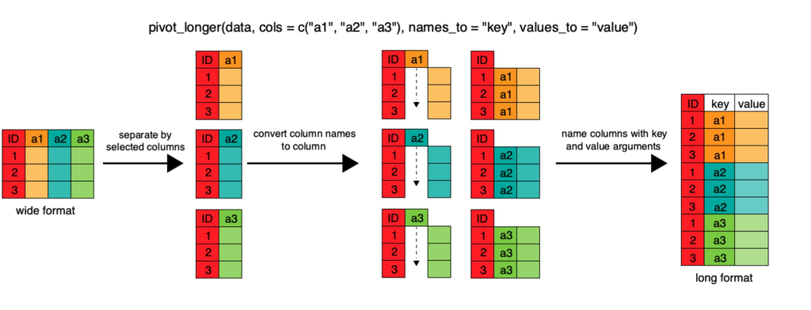

## 3.5 Pivot tables

These beasts can be incredibly useful. They require two steps:

1. Determine the **dimensions** (categorical columns) along which to perform the analysis: this is done with **group_by()**;
2. Define the **key metrics** to compute: this is done with **summarize()**.

```r
wb_data |>
  filter(year == 2023, region != "Aggregates") |>
  group_by(region) |>
  summarise(total_population = sum(pop))
```

| region | total_population |
| --- | --- |
| East Asia & Pacific | 2361106057 |
| Europe & Central Asia | 925640799 |
| Latin America & Caribbean | 654413871 |
| Middle East & North Africa | 508842198 |
| North America | 376954413 |
| South Asia | 1951539835 |
| Sub-Saharan Africa | 1241543738 |

Below, “na.rm = T” means that NA data will be removed before applying the function.

```r
wb_data |>
  filter(region != "Aggregates") |>
  group_by(region, year) |>
  summarise(avg_gdp_percap = mean(gdp_percap, na.rm = T)) |>
  head(8)
```

| region | year | avg_gdp_percap |
| --- | --- | --- |
| East Asia & Pacific | 1960 | 522.1182 |
| East Asia & Pacific | 1961 | 535.4375 |
| East Asia & Pacific | 1962 | 546.7194 |
| East Asia & Pacific | 1963 | 594.2096 |
| East Asia & Pacific | 1964 | 636.9282 |
| East Asia & Pacific | 1965 | 785.9105 |
| East Asia & Pacific | 1966 | 839.3606 |
| East Asia & Pacific | 1967 | 795.2839 |

```r
wb_data |>
  group_by(income) |>
  summarise(avg_gdp_percap = mean(gdp_percap, na.rm = T))
```

| income | avg_gdp_percap |
| --- | --- |
| Aggregates | 5285.0354 |
| High income | 22472.9538 |
| Low income | 433.7686 |
| Lower middle income | 1150.8568 |
| Not classified | 4101.0849 |
| Upper middle income | 3475.4895 |
| NA | 4405.7019 |

## 3.6 Plots

In “**ggplot**”, the GG stands for **grammar of graphics**, a very neat way to think of plots.  
It decomposes graphs into specific elements (layers), see illustration below.

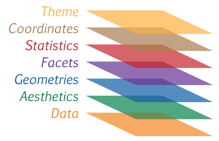

Of the above, only the bottom 3 are indispensable. The above one are for customization.

Look at the %in% operator below… much better than OR |

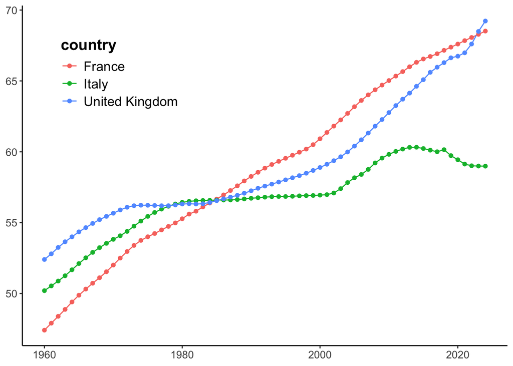

```r
wb_data |>
  filter(country %in% c("France", "Italy", "United Kingdom")) |>
  ggplot(aes(x = year, y = pop/10^6, color = country)) +
  geom_line() + geom_point() +
  theme_classic() +
  theme(axis.title = element_blank(),
        text = element_text(size = 13),
        legend.text = element_text(size = 13),
        legend.title = element_text(face = "bold", size = 15),
        legend.position = c(0.2,0.8))
```

A closer look at the syntax:

$$\underbrace{\text{ggplot}}_{\substack{\text{function} \\ \text{call}}}\left(\underbrace{\text{aes}(\text{x = } \overbrace{\text{year}}^{\substack{\text{column} \\ \text{name}}}, \ \text{y = } \overbrace{\text{population}}^{\substack{\text{column} \\ \text{name}}}}_{\text{aesthetics}})\right) \ + \ \underbrace{\text{geom_line()}}_{\substack{\text{geometry}\\ \text{(graph type)}}}$$

Both elements the **aesthetics** and the **geom type** are crucial.  
Also, mind the “+” that separates the layers, it is **not a pipe**!

Another example, using a recycled pivot table.  
na.omit() removes rows with missing data.

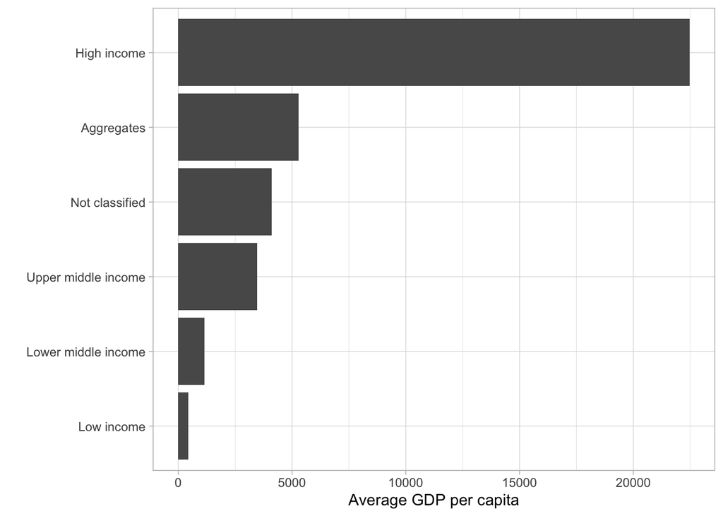

```r
wb_data |>
  group_by(income) |>
  summarise(avg_gdp_percap = mean(gdp_percap, na.rm = T)) |>
  na.omit() |>
  ggplot(aes(y = reorder(income, avg_gdp_percap), x = avg_gdp_percap)) + geom_col() +
  xlab("Average GDP per capita") + ylab("") +
  theme_light()
```

A last one for the road.

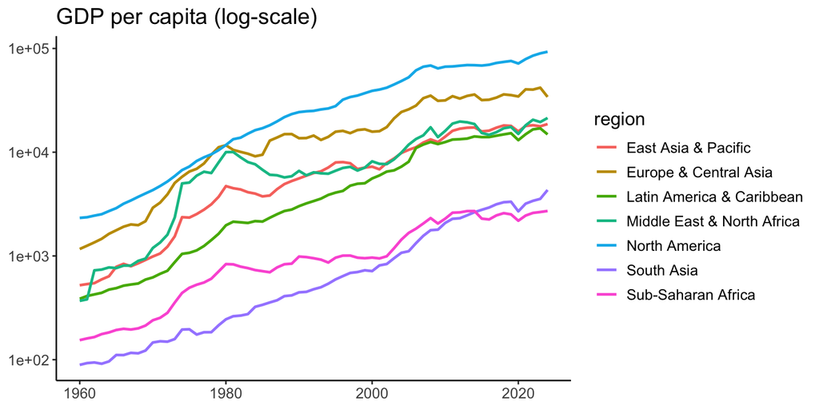

```r
wb_data |>
  filter(region != "Aggregates") |>
  group_by(region, year) |>
  summarise(avg_gdp_percap = mean(gdp_percap, na.rm = T)) |>
  ggplot(aes(x = year, y = avg_gdp_percap, color = region)) + geom_line(linewidth = 0.9) +
  scale_y_log10() + theme_classic() +
  theme(axis.title = element_blank(),
        text = element_text(size = 13)) +
  ggtitle("GDP per capita (log-scale)")
```

# 4 Other datasets

## 4.1 Airline traffic

Let’s have a look at some data. Below, we dive into airline traffic, obtained from [Aéroport de Paris](https://www.parisaeroport.fr/en/group/finance/investor-relations/traffic).[^1]

Upon inspection, we need to open the third spreadsheet and focus on the first three columns:

- **date**
- **number of passengers for CDG**
- **number of passengers for ORY**

This file was manually edited to avoid errors (duplicated dates in the original sample.).

```r
url <- "https://github.com/shokru/coqueret.github.io/raw/refs/heads/master/files/misc/time_series/traffic-sheet.xlsx"
airline <- read.xlsx(url, sheet = 3, startRow = 2)
head(airline)
```

```
     X1 Paris.-.Charles.de.Gaulle Paris.-.Orly   Total
1 36526                   3223328      1935261 5158589
2 36557                   3289676      1942750 5232426
3 36586                   3891206      2204640 6095846
4 36617                   4221430      2266448 6487878
5 36647                   4217758      2203570 6421328
6 36678                   4279344      2190218 6469562
  Paris.-.Charles.de.Gaulle Paris.-.Orly Total
1                     39489        19956 59445
2                     38386        19347 57733
3                     42049        21286 63335
4                     42931        20192 63123
5                     43909        20921 64830
6                     41966        19331 61297
```

Next, let do a bit of wrangling.

```r
air_data <- airline |> select(1:3)                  # Keep only the first 3 columns
colnames(air_data) <- c("date", "CDG", "ORY")       # Rename these columns
air_data <- air_data |>                              # Reformat the date
  mutate(date = as.Date(as.numeric(date), origin = "1899-12-30")) |>
  filter(is.finite(date), is.finite(CDG)) |>
  arrange(date)
```

To make the most of the `{fable}` [package](https://fable.tidyverts.org), we need to embed the dataframe into a **tsibble**, a kind of strange animal (data format) that the package really likes.

```r
air_data <- air_data |>
  mutate(date = yearmonth(date)) |>
  distinct(date, .keep_all = T) |>
  as_tsibble() |>
  fill_gaps()
```

Let’s plot all of this!

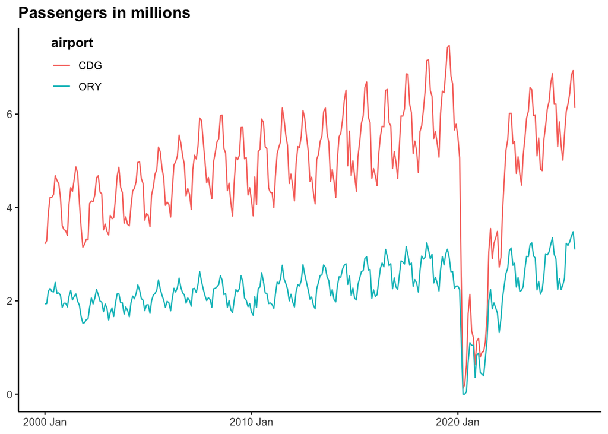

```r
air_data |>
  pivot_longer(-date, names_to = "airport", values_to = "passengers") |>
  ggplot(aes(x = date, y = passengers/10^6, color = airport)) + geom_line() +
  theme_classic() + ggtitle("Passengers in millions") +
  theme(axis.title = element_blank(),
        title = element_text(face = "bold"),
        legend.position = c(0.1,0.9))
```

What are some patterns that we can identify?

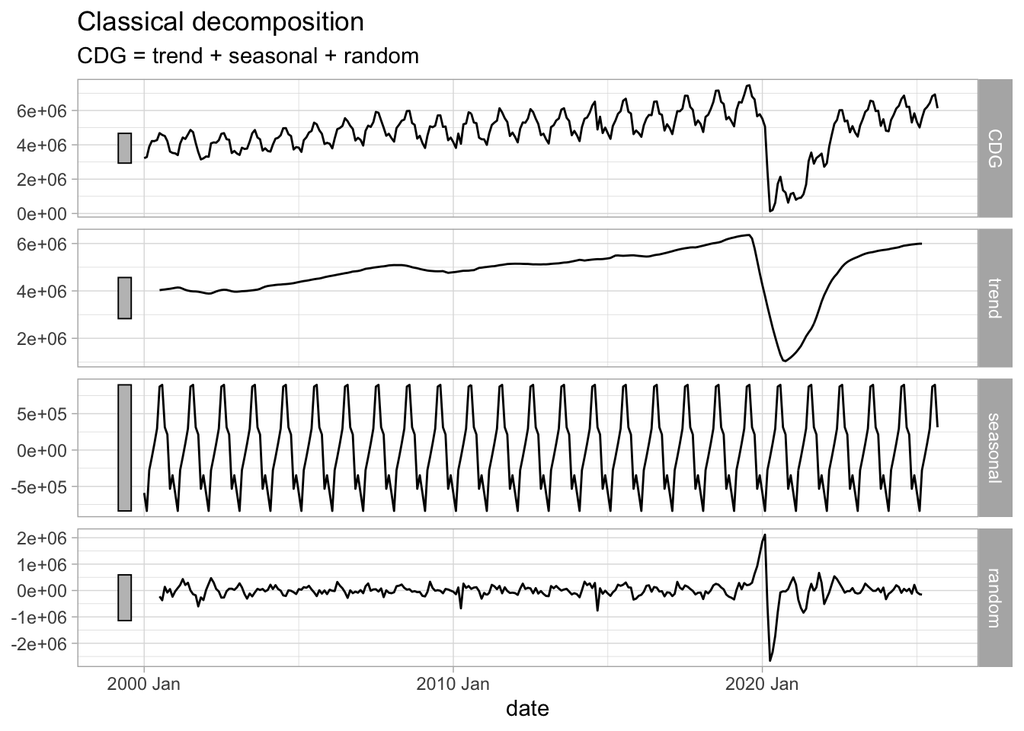

```r
air_data %>%
  model(classical_decomposition(CDG)) %>%
  components() %>%
  autoplot() + theme_light()
```

## 4.2 Atmospheric CO2 concentration

```r
url <- "https://gml.noaa.gov/webdata/ccgg/trends/co2/co2_mm_mlo.csv"
co2 <- read.csv(url, skip = 40)
co2 <- co2 |>
  mutate(date = make_date(year = year, month = month, day = 15)) |>
  select(date, average, deseasonalized) |>
  mutate(date_iso = date,
         date = yearmonth(date)) |>
  as_tsibble(index = date)
```

A sneak peek…

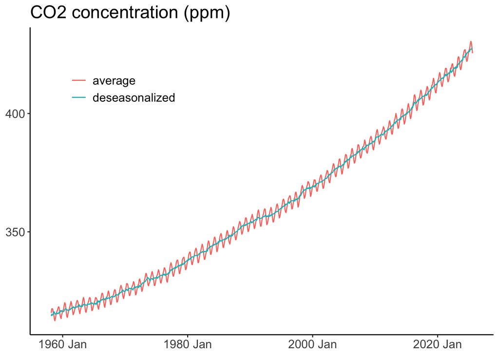

```r
co2 |>
  pivot_longer(-c(date, date_iso), names_to = "series", values_to = "value") |>
  ggplot(aes(x = date, y = value, color = series)) + geom_line() +
  theme_classic() + ggtitle("CO2 concentration (ppm)") +
  theme(legend.position = c(0.2,0.8),
        text = element_text(size = 15),
        legend.title = element_blank(),
        axis.title = element_blank())
```

How can we explain the oscillations?  
Let’s decompose this.

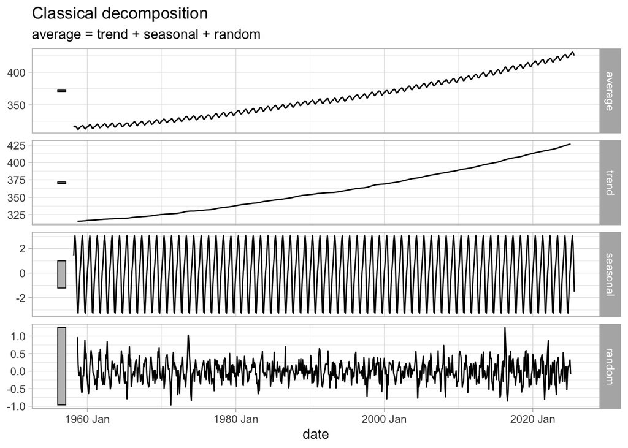

```r
co2 %>%
  model(classical_decomposition(average)) %>%
  components() %>%
  autoplot() +
  theme_light()
```

## 4.3 Financial series

### 4.3.1 Stocks

```r
tickers <- c("AAPL", "BA", "C", "PFE", "WMT", "XOM")
# Tickers: Apple, Boeing, Citigroup, Pfizer, Walmart, Exxon
# Others: , "F", "DIS", "GE", "CVX", "MSFT", "GS"
min_date <- "2000-01-01"                      # Starting date
max_date <- "2025-10-30"                      # Ending date
prices <- getSymbols(tickers, src = 'yahoo',  # The data comes from Yahoo Finance
                     from = min_date,         # Start date
                     to = max_date,           # End date
                     auto.assign = TRUE,
                     warnings = FALSE) %>%
  map(~Ad(get(.))) %>%                        # Retrieving the data
  reduce(merge) %>%                           # Merge in one dataframe
  `colnames<-`(tickers)                       # Set the column names
prices |> tail()
```

```
             AAPL     BA      C   PFE    WMT    XOM
2025-10-22 258.45 216.59  96.30 24.72 107.14 114.71
2025-10-23 259.58 217.77  96.69 24.67 106.86 115.98
2025-10-24 262.82 221.35  98.78 24.76 106.17 115.39
2025-10-27 268.81 223.00 100.99 24.77 104.47 115.94
2025-10-28 269.00 223.33 101.39 24.50 103.17 115.03
2025-10-29 269.70 213.58  99.12 24.29 102.46 116.45
```

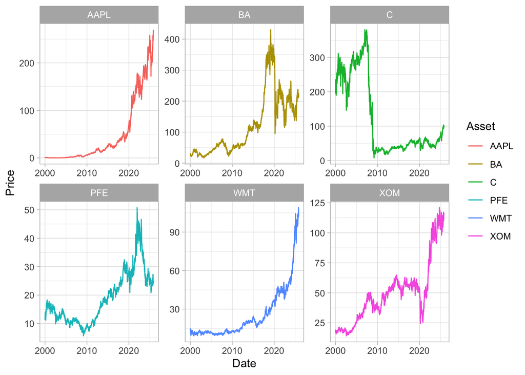

```r
prices %>%
  as.data.frame() %>%
  rownames_to_column(var = "Date") %>%
  mutate(Date = as.Date(Date)) |>
  pivot_longer(-Date, names_to = "Asset",
               values_to = "Price") %>%
  ggplot(aes(x = Date, y = Price, color = Asset)) + geom_line() +
  facet_wrap(vars(Asset), scales = "free") + theme_light()
```

Any **pattern** that you can recognize?

### 4.3.2 Cryptocurrencies

We will use the `{crypto2}` package below. If need be: install it.  
First, let’s have a look at the list of available coins… which are numerous!

```r
coins <- crypto_list()
```

You can have a look at the info for the coins via the code below.

```r
c_info <- crypto_info(coin_list = coins, limit = 30)
```

```
❯ Scraping crypto info
```

```
❯ Processing crypto info
```

Next, we can download **historical quotes**.  
Symbols have duplicates, we need to use “slugs”.

```r
coin_symb <- c("bitcoin", "ethereum", "tether", "xrp")
coin_hist <- crypto_history(coins |> dplyr::filter(slug %in% coin_symb),
                            start_date = "20170101",
                            end_date = "20250925")
```

```
❯ Scraping historical crypto data
```

```
❯ Processing historical crypto data
```

```r
coin_hist <- coin_hist |>  # Timestamps are at midnight.
  mutate(date = as.Date(as.POSIXct(timestamp, origin="1970-01-01")))
```

Mind the log-scale!

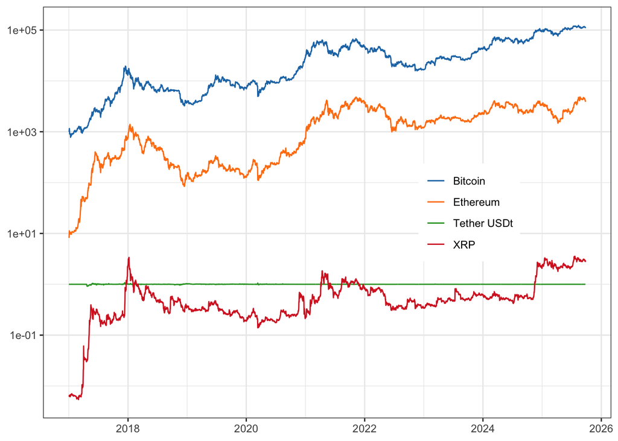

```r
coin_hist |>
  ggplot(aes(x = date, y = close, color = name)) + geom_line() +
  scale_y_log10() + theme_bw() + scale_color_d3() +
  theme(legend.position = c(0.75,0.5),
        axis.title = element_blank(),
        legend.title = element_blank())
```

Any **pattern** that you can recognize here again?

Unfortunately, this kind of data is hard to analyze directly - more on that next time!

# 5 Descriptive statistics (to be done in class)

Pick a dataset… & explore!

1. What is the average rate of increase of CO$_2$ in the atmosphere?
2. Using the code below, determine during which month airports see the most passengers.
3. Which stock/crypto had the best performance over the sample we downloaded?
4. Which country is the richest (GDP per capita), and which one spends the most on R&D, or education?

```r
air_data |> mutate(month = month(date))
```

# 6 Wrap-up

The things you need to remember:

- the **tidyverse** functions: filter, select, arrange, mutate, group_by and summarize. They are incredible tools to analyze data rapidly.
- There are a small number of patterns that are easy to recognize (seasonality, trends). But there are also unpredictable shocks, some small, some very large. It is these shocks that we will try to model henceforth.

## Footnotes

[^1]: See at the bottom of the page, downloaded in October and covering 2000-2025.